# Support Vector Machines (SVM)

### **NOTES ON STATISTICS, PROBABILITY and MATHEMATICS**

### Support Vector Machines (SVM):

From this [MIT video](https://youtu.be/_PwhiWxHK8o).

It is predicated upon drawing a decision boundary line leaving as ample a margin to the first positive and negative examples as possible:

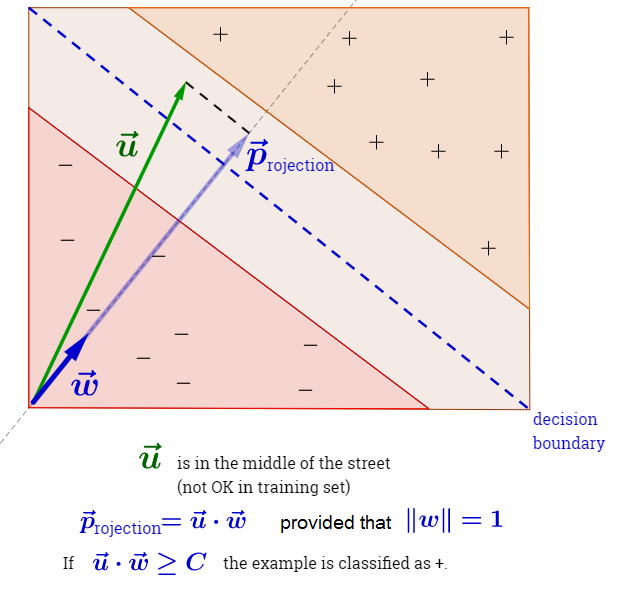

As in the illustration above, if we select an orthogonal vector such that $\large \lVert w \rVert=1$ we can establish a decision criterium for any unknown example $\bf u$ to be catalogued as positive of the form:

$\large \color{blue}{w} \cdot {\bf u} \geq c$, corresponding to a value that would place the projection beyond the decision line in the middle of the street. Notice that $\color{blue}{w} \cdot {\bf u} = {\bf u} \cdot \color{blue}{w}$.

An equivalent condition would be:

$$\Large\color{blue}{w}\cdot u + b \geq 0
\tag{decision line or rule: Eq.1}$$

with $c = - b$ the sample is positive.

So we need $b$ and $\color{blue}{w}$ to have a decision rule. To get there we need *constraints*.

First constraint we are going to impose is that for any positive sample $x_+$ (we could have used $u_+$), $\color{blue}{w}\cdot \bf x_+ + b \geq 1$; and for negative samples, $\color{blue}{w}\cdot \bf x_- + b \leq -1$.

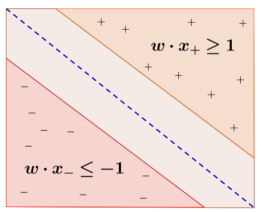

In the division boundary or hyperplane (**median**) the value would be $0$, leaving the values of the different strips as:

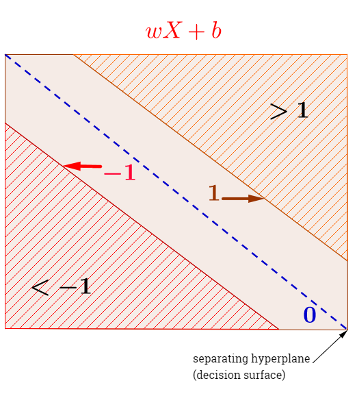

The vector $\bf w$ is the **weight vector**, whereas $b$ is the **bias**.

To bring these two inequalities together, we can introduce the variable $y_i$ so that $y_i=+1$ for positive examples, and $y_i=-1$ if the examples are negative, and conclude $\large y_i (x_i\cdot \color{blue}{w} + b) -1\geq 0$.

So we establish that this has to be greater than zero, *but* if the example is on the hyperplanes that maximize the margin of separation between the decision hyperplane and the tips of the support vectors, in this case a lines), then:

$$\Large y_i \,(x_i\cdot \color{blue}{w} +
b) -1 = 0\tag{Eq.2}$$

Notice that this is equivalent to requiring that $y_i \,(x_i\cdot \color{blue}{w} + b) = 1.$

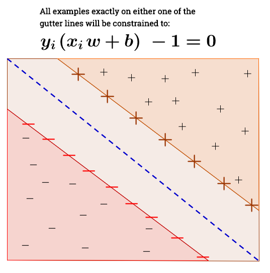

Second constraint: the distance of the decision hypeplane to the tips of the support vectors will be maximized. In other words the **margin of separation (“street”)** will be maximized:

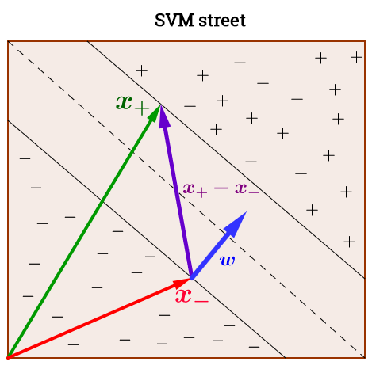

Again, assuming a unit vector perpendicular to the decision boundary, the dot product with the difference between two “bordering” plus and minus examples is the width of “the street”:

$$\large \text{width}= (x_+ \,{\bf -}\,
x_-) \cdot \frac{w}{\lVert w \rVert} \tag{the width of the
street}$$

Now, key observation: on the equation above $x_+$ and $x_-$ *are* in the gutter (on hyperplanes maximizing the separation)! Therefore, for the positive example:

$\large ({\bf x_i}\cdot \color{blue}{w} + b) -1 = 0$, or $\large {\bf x_+}\cdot \color{blue}{w} = 1 - b$; and for the negative example: $\large {\bf x_-}\cdot \color{blue}{w} = -1 - b$. So, reformulating the width of the street:

$$\begin{align}\text{width}&=(x_+
\,{\bf -}\, x_-) \cdot \frac{w}{\lVert w \rVert}\\&= \frac{x_+\cdot
w \,{\bf -}\, x_-\cdot w}{\lVert w
\rVert}\\&=\frac{1-b-(-1-b)}{\lVert w \rVert}\\&=
\frac{2}{\lVert w \rVert} \tag{the width of the street:
Eq.3}\end{align}$$

So now we just have to maximize the width of the street - maximize $\large \frac{w}{\lVert w \rVert}$ (or maximize $\Large \frac{2}{\lVert w \rVert}$, or minimize $\Large \lVert w \rVert)$, or minimize:

$$\large \text{min}\frac{1}{2}\lVert w
\rVert^2 \tag{minimization objective: Eq.4}$$

which is mathematically convenient.

So we want to:

1. Minimize $\lvert x\rvert^2$ with the constraint:
2. $y_i(x_i\cdot w + b)-1=0$

So we want to minimize this expression based on some constraints. Hence we need a Lagrange multiplier (going back to equations 2 and 4):

$$\large \mathscr{L} = \frac{1}{2} \lVert
w \rVert^2 - \sum \lambda_i \Big[y_i \, \left( x_i\cdot \color{blue}{w}
+ b \right) -1\Big]\tag{Lagrange: Eq.5}$$

Differentiating,

$\large \frac{\partial \mathscr{L}}{\partial \color{blue}{w} }= \color{blue}{w} - \sum \lambda_i y_i x_i = 0$. Therefore,

$$\large\color{blue}{w} = \sum \lambda_i
\,\, y_i \,\, x_i\tag{Orthonormal vector: Eq.6}$$

$\large \frac{\partial \mathscr{L}}{\partial b}=-\sum \lambda_i y_i = 0$, which means that

$\large \sum \lambda_i \, y_i = 0\tag{zero sum multipliers times labels: Eq.7}$

Pluging equation [Eq.6] back into [Eq.5],

$$\mathscr{L} = \frac{1}{2}
\color{purple}{\left(\sum \lambda_i y_i x_i \right) \,\left(\sum
\lambda_j y_j x_j \right)}- \color{green}{\left(\sum \lambda_i
y_i x_i\right)\cdot \left(\sum \lambda_j y_j x_j \right)} - \sum
\lambda_i y_i b +\sum \lambda_i$$

The penultimate term is zero as per equation [Eq.7].

Therefore,

$$\bbox[15px,border:2px solid blue]{\large
\mathscr{L} = \sum \lambda_i - \frac{1}{2}\displaystyle \sum_i
\sum_j \lambda_i \lambda_j\,\, y_i y_j \,\, x_i \cdot x_j}\tag{final
Lagrangian: Eq.8}$$

Hence, the optimization depends on the dot product of pairs of examples.

Going back to the “decision rule” equation [Eq.1] above, and using [Eq.6]:

$$\large \sum \lambda_i y_i x_i\cdot u +
b \geq 0\tag{final decision rule: Eq.9}$$

[Home Page](http://rinterested.github.io/statistics/index.html)

**NOTE: These are tentative notes on different topics for personal use - expect mistakes and misunderstandings.**